# Proyecto

# 1 Introducción

## 1.1 Relevancia

Es necesario para cualquier centro educativo entender la perspectiva de sus alumnos respecto a este. Teniendo en cuenta que desde el inicio de la pandemia y su posterior época de recuperación económica, tenemos que la deserción universitaria en Lima alcanzó casi el 30%. Según el MINEDU, antes de la pandemia, la tasa de interrupción de estudios universitarios fue de 12.6% en el ciclo 2019-2 y posteriormente, ante la llegada del COVID-19, aumentó a 18.3% para el semestre 2020-1. A su vez, teniendo en cuenta que la retención del alumnado es uno de los factores más importantes en los que se puede centrar cualquier centro educativo, este estudio también puede ayudar a entender la opinión de los alumnos frente a su universidad y encontrar posibles áreas de mejora.

## 1.2 Planificación

**Objetivos**

*Objetivo general*:

Identificar los posibles factores de deserción que posean los alumnos de pre-grado desde primer a noveno ciclo en el periodo académico 2022-1.

*Objetivos específicos*:

1. Obtener la media, mediana y moda de las edades de los encuestados.
2. Encontrar una relación entre la edad de los encuestados y sus deseos de retirarse de la universidad.
3. Revisar la relación entre los deseos de retirarse de la universidad y motivos por los cuales lo harían.
4. Hallar una relación entre la cantidad de horas de sueño promedio y los índices de desgaste emocional.
5. Revisar la relación entre tener como posible motivo de deserción los altos y costos y la escala de pago en la que se encuentra el o la estudiante.
6. Establecer una relación entre personas que si desertarían o tal vez desertarían en base a su desgaste emocional y promedio ponderado.

**Tabla**

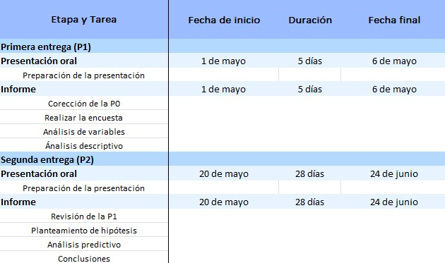

**Diagrama de Grant**

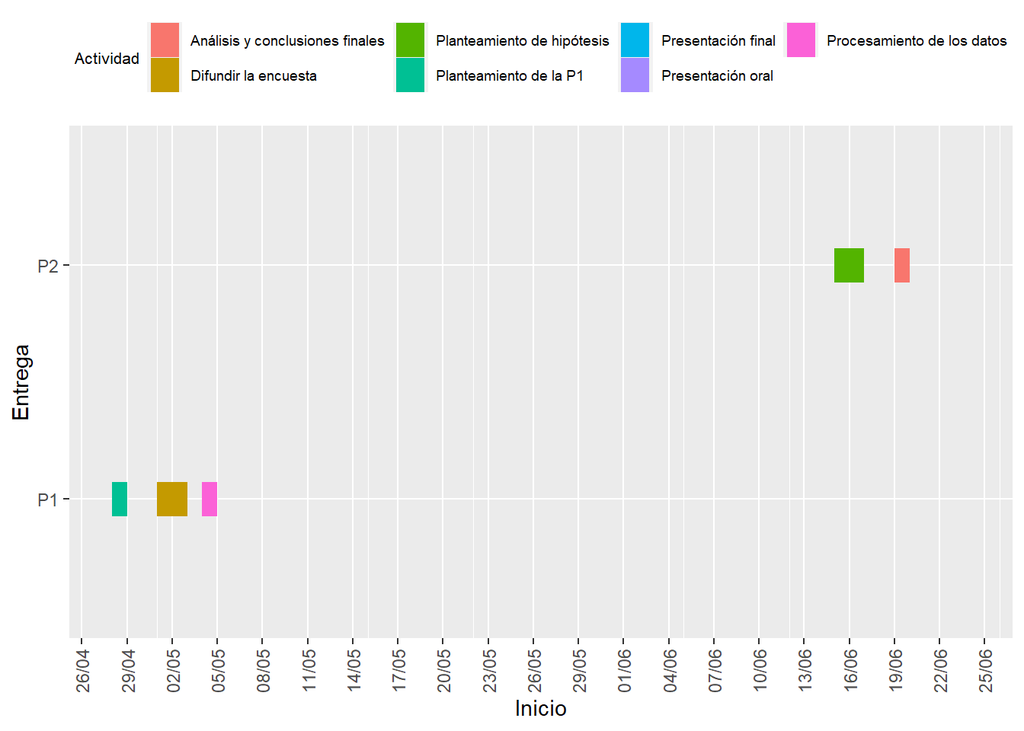

```r
data <- data.frame(Entrega = c('P1', 'P1', 'P1', 'P1', 'P2', 'P2', 'P2'),
Inicio = c("28/04", "01/05", "04/05","06/05", "15/06", "19/06", "24/06"),
Fin = c("29/04", "03/05", "05/05","06/05", "17/06", "20/06", "24/06"),
Actividad = c("Planteamiento de la P1", "Difundir la encuesta", "Procesamiento de los datos","Presentación oral", "Planteamiento de hipótesis", "Análisis y conclusiones finales", "Presentación final"))

data$Inicio <- as.Date(data$Inicio,'%d/%m')
data$Fin <- as.Date(data$Fin,'%d/%m')

if(!require(ggplot2)){install.packages('ggplot2')}
ggplot(data, aes(x=Inicio, xend=Fin, y=Entrega, yend=Entrega, color=Actividad)) +
  geom_segment(size=8)+ theme(axis.text.x = element_text(angle = 90, vjust = 0.5, hjust=1),legend.position='top',legend.title=element_text(size=8), legend.text=element_text(size=7))+  scale_x_date(date_breaks = "3 day", date_minor_breaks = "1 week", date_labels = "%d/%m")
```

# 2 Datos

## 2.1 Proceso de recolección de datos

Al ser este un estudio en donde la información se obtendrá mediante encuestas, lo primero que se hizo fue difundir mediante las redes sociales de los integrantes del grupo, en estados de *WhatsApp e Instagram*, compartiendo el link del forms y explicando de manera breve que es lo que buscamos con este trabajo. Mediante esta primera parte de la difusión logramos alcanzar un 40% de nuestro objetivo (200 encuestados). Después para conseguir más respuestas procedimos a encuestar al alumnado cuando se disolvió el método de ingreso a la universidad mediante grupos divididos por apellidos. Se encuestó a estudiantes que se encontraban en el piso 6 y piso 1, además de otros alumnos que comparten cursos los miembros del equipo, mediante lo cual alcanzamos el 75% de nuestra meta. Finalmente, decidimos volver a difundir la encuesta a personas que comparten los mismos talleres extracurriculares (clubs) que los integrantes.

## 2.2 Población, muestra, y muestreo

**Población**

Nuestra población es de todos los estudiantes que se encuentran en UTEC estudiando un pre-grado desde primer a noveno ciclo en el periodo 2022-1.

**Muestra**

**Tamaño de error muestral**

Tomando de referencia el censo realizado en el periodo académico 2021-1 tenemos que en la Universidad de Ingeniería y Tecnología (UTEC) se encuentran cursando *3475* alumnos de pre-grado. Teniendo una muestra de *203* alumnos y recordando la fórmula para obtener el error muestral **( puntuación z * (desviación estándar / raíz del tamaño de la muestra) )** podemos realizar dos evaluaciones. La primera, teniendo en consideración que se quiera un nivel de confianza de *95* nos dejaría un error margen de error de 6.68%. La segunda prueba por hacer es teniendo en consideración un nivel de confianza de *85*, lo que nos daría un margen de error de 4.90%. Viendo que el nivel de confianza más apropiado es la de 95, pero que nuestro margen de error excede el 5% podemos realizar la observación de que nuestro tamaño de muestra debería de ser de mínimo *346* para lograr un margen de error de 5% en un nivel de confianza de 95 y de dicha manera obtener una encuesta más representativa.

**Muestreo**

El tipo de muestreo que hemos utilizado para esta investigación es el *muestreo por conveniencia*. Lo anterior debido a que, siendo la población de la universidad extensa, se prefirió que no sea totalmente aleatorio por la alta cantidad de tiempo que requiere, por lo que se optó por tomar como conjunto muestral a jóvenes del entorno cercano a los investigadores, es decir, gente con la que se comparte clases, círculo amical, compañeros de actividades extracurriculares y estudiantes que frecuentan lugares en común con los integrantes del grupo.

## 2.3 Variables

Lo que hicimos primero fue separar las variables en base a la información que nos brindaban, esto fue en: General, Desempeño académico, Aspecto Financiero, Salud, Emocional y Deserción.

**General** :

```r
General <- read.csv("Variables_Generales.csv")
General
```

```
##   ï..Variable                        Tipo
## 1        Edad  Variable numerica discreta
## 2        Sexo Variable categorica nominal
## 3       Ciclo  Variable numerica discreta
## 4     Carrera Variable categorica nominal
##                                                             Restriccion
## 1                                      Cualquier numero entero positivo
## 2                          Opcion para marcar con: Hombre, Mujer, Otros
## 3                                                           Del 1 al 10
## 4 Opcion para seleccionar cualquiera de las carreras que hay en la UTEC
```

**Desempeño académico** :

```r
Academico <- read.csv("Variables_Academicas.csv")
Academico
```

```
##                                      ï..Variable                       Tipo
## 1                             Promedio ponderado Variable numerica continua
## 2 Veces que cursaste un curso en 2 oportunidades Variable numerica discreta
## 3 Veces que cursaste un curso en 3 oportunidades Variable numerica discreta
## 4     Cantidad de cursos matriculados este ciclo Variable numerica discreta
##                              Restriccion
## 1 Cualquier numero positivo entre 0 y 20
## 2       Cualquier numero entero positivo
## 3       Cualquier numero entero positivo
## 4    Cualquier numero entero entre 2 y 8
```

**Aspecto Financiero** :

```r
Financiero <- read.csv("Variables_Economicas.csv")
Financiero
```

```
##                       ï..Variable                        Tipo
## 1                          Escala Variable categorica ordinal
## 2        Opiniones credito escala Variable categorica nominal
## 3                            Beca Variable categorica nominal
## 4 Gasto por asesorias adicionales  Variable numerica continua
##                         Restriccion
## 1 Cualquier letra entre la A y la E
## 2             Valores entre Si y No
## 3             Valores entre Si y No
## 4         Cualquier numero positivo
```

**Salud** :

```r
Salud <- read.csv("Variables_Salud.csv")
Salud
```

```
##                                 ï..Variable                        Tipo
## 1                 Horas promedio que duerme  Variable numerica continua
## 2         Cantidad de veces que come al dia  Variable numerica continua
## 3           Perspectiva de su rutina diaria Variable categorica ordinal
## 4 Oraciones que le identifican dicha semana Variable categorica nominal
##                                                                                                                                                                                                                                       Restriccion
## 1                                                                                                                                                                                                                       Cualquier numero positivo
## 2                                                                                                                                                                                                                    Cualquier numero entre 1 y 8
## 3                                                                                                                                                                                                                     Cualquier numero del 1 al 5
## 4 Llorar por estres = 1. Salir a relajarse un rato = 0. No dormir lo adecuado = 1. Estar tranquilo(a) = 0. Sentir mucho cansancio = 1. Estar emocionado(a)/feliz = 0. No querer hacer nada = 1. Sentir mucha motivaciÃ³n = 0. Malestar fisico = 1
##                               Informacion.adicional
## 1                                                -
## 2                                                 -
## 3                    1 siendo poco y 5 siendo mucho
## 4 Cosas positivas valen 0 y cosas negativas valen 1
```

**Emocional** :

```r
Emocional <- read.csv("Variables_Emocionales.csv")
Emocional
```

```
##                                        ï..Variable                       Tipo
## 1 Sentimientos antes de quizzes, tareas o entregas Variable numerica continua
## 2                        Sentimientos en parciales Variable numerica continua
## 3          Sentimientos positivos la ultima semana Variable numerica continua
## 4          Sentimientos negativos la ultima semana Variable numerica continua
##                                                                                                                    Restriccion
## 1 Inseguridad = 1, Nerviosismo = 1, Tranquilidad = 0, Confianza = 0, Preocupacion = 1,  Exaltacion = 0, Fatiga = 1, Pasion = 0
## 2                Entusiasmo = 0, Ansiedad = 1,  Cansancio = 1, Miedo = 1, Estres = 1, Emocion = 0, Seguridad = 0, Vocacion = 0
## 3                                                               Evaluando que tanto se rio, disfruto y que tan feliz se sintio
## 4                                                         Evaluando que tanto se enojo, se preocupo y que tan triste se sintio
##                                      Informacion.adicional
## 1   Sentimientos negativos valen 1 y los positivos valen 0
## 2   Sentimientos negativos valen 1 y los positivos valen 0
## 3 Los 3 se evaluan en una escala del 1 (poco) al 5 (mucho)
## 4 Los 3 se evaluan en una escala del 1 (poco) al 5 (mucho)
```

**Deserción** :

```r
Desercion <- read.csv("Variables_Desercion.csv")
Desercion
```

```
##                                        ï..Variable                        Tipo
## 1                Consideraria dejar la universidad Variable categorica nominal
## 2 Motivos por los cuales si dejaria la universidad Variable categorica nominal
##                                                                                                    Restriccion
## 1                                                                                Elegir entre Si, No y Tal vez
## 2 Altos costos, Circunstancias familiares, Desgaste emocional, Alto nivel de dificultad, Otros (especificar)\n
```

## 2.4 Limpieza de base de datos

Lo primero que podríamos hacer es realizar una inicialización de las librerías que necesitaremos para trabajar en nuestro informe:

```r
library(readr)
library(dplyr)
```

Lo segundo que hicimos fue realizar un pre-procesamiento de la data obtenida de la encuesta y llevada a un documento de Google:

```r
DF0 <- read_csv("Datos_Iniciales.csv")
```

En el anterior archivo csv se utilizó un pre-procesamiento manual de parte de los miembros del grupo para la modificación de las columnas *‘Selecciona las frases que te identifican esta semana’*, ‘*¿Con qué sentimientos te identificas antes de dar un examen, PC, o test semanal?*’ y ‘¿*Con qué sentimientos te identificas en la época de parciales?*’

Dicho procesamiento fue realizado en base a lo previamente especificado en la parte de **Variables - Emocional**, en donde se le había realizado una designación inicial a las oraciones y sentimientos. Por lo que una vez modificado el archivo nos quedamos con lo siguiente:

```r
library("readr")
DF <- read_csv("Datos_Finales.csv")
```

Lo siguiente que hacemos es verificar el estado de nuestras variables, es decir, revisar si R lee los datos de la manera que queremos que lo haga

```r
spec(DF)
```

Teniendo que los únicos datos que se deberían de limpiar son: “Género”, “Promedio ponderado”, “Lo gastado en asesorías”, “Horas de sueño promedio” y “Motivos por los que se dejaría la universidad”, empezaremos a hacer la limpieza en dicho orden. Por lo cual les cambiamos el nombre para proceder con un manejo más sencillo de estas:

```r
DF %>% rename (Gen = Género
               , Prom = `Promedio ponderado`
               , Asesorías = `¿Cuánto has gastado en asesorías adicionales para tus cursos este ciclo?`
               , Sueño = `¿Cuántas son tus horas de sueño promedio?`
               , Motivos = `Si la respuesta anterior es sí, ¿Por qué motivos?`)
```

```
## # A tibble: 203 x 28
##    `Marca temporal` Gen     Edad Ciclo Carrera       Prom Veces que tomaste un~1
##    <chr>            <chr>  <dbl> <dbl> <chr>        <dbl>                  <dbl>
##  1 5/01/2022 17:44  Mujer     22     3 Ingeniería ~  14.2                      1
##  2 5/01/2022 17:46  Mujer     18     3 Ingeniería ~  16                        0
##  3 5/01/2022 17:46  Mujer     18     3 Bioingenier~  15.5                      0
##  4 5/01/2022 17:47  Mujer     18     3 Bioingenier~  15.9                      0
##  5 5/01/2022 17:48  Hombre    30     3 Ingeniería ~  16                        0
##  6 5/01/2022 17:56  Hombre    22     3 Ingeniería ~  15.3                      0
##  7 5/01/2022 18:10  Mujer     26     5 Bioingenier~  13                        3
##  8 5/01/2022 18:12  Hombre    19     3 Bioingenier~  13                        2
##  9 5/01/2022 18:14  Hombre    18     3 Ingeniería ~  12.9                      2
## 10 5/01/2022 18:15  Hombre    18     3 Ingeniería ~  15.2                      0
## # i 193 more rows
## # i abbreviated name: 1: `Veces que tomaste un mismo curso en 2 oportunidades`
## # i 21 more variables:
## #   `Veces que tomaste un mismo curso en 3 oportunidades` <dbl>,
## #   `Cantidad de cursos matriculados este ciclo` <dbl>,
## #   `Grado de dificultad promedio de los cursos de este ciclo` <dbl>,
## #   `¿En qué escala de pago te encuentras?` <chr>, ...
```

Ya procediendo con la limpieza de los datos tenemos lo siguiente:

*Género*:

```r
DF$Género[DF$Género == "no binario"] <- "No Binario"
DF$Género[DF$Género == "No binario"] <- "No Binario"
```

```r
DF$Género <- gsub("16", "", DF$Género)
DF$Género[DF$Género == ""] <- NA
```

Comprobamos que nuestra limpieza haya sido efectiva mediante:

```r
unique(DF$Género)
```

```
## [1] "Mujer"      "Hombre"     "No Binario" NA
```

*Promedio ponderado*:

```r
unique(DF$`Promedio ponderado`)
```

```
##  [1] 14.25 16.00 15.50 15.90 15.30 13.00 12.87 15.23 15.75 14.00 17.55 15.00
## [13] 12.52 18.12 14.30 17.10 14.50 16.20 16.40 17.00 13.25 15.40 15.15 15.13
## [25] 16.75 14.70 17.90 13.87 13.63 13.30 15.20 18.00 12.00 15.65 10.00 17.21
## [37] 15.56 18.40 16.79 14.89 13.23 14.05 12.50 11.43 15.80 13.20 17.50 15.41
## [49]  0.00 15.55 14.75 14.44 17.70 20.00 16.76 15.60 13.95 15.45 14.55 16.10
## [61] 16.70 13.85 14.90 16.30 14.60 13.40 13.74 15.10 15.95 15.25 17.20 17.30
## [73] 14.32 17.22 14.10 14.31 12.40 15.72 16.55
```

```r
class(DF$`Promedio ponderado`)
```

```
## [1] "numeric"
```

```r
DF$`Promedio ponderado` <- gsub("00", "", DF$`Promedio ponderado`)
DF$`Promedio ponderado` <- gsub("20", "", DF$`Promedio ponderado`)
```

```r
DF$`Promedio ponderado`[DF$`Promedio ponderado` == ""] <- NA
```

```r
DF$`Promedio ponderado`[DF$`Promedio ponderado` == "15."] <- "15"
```

```r
DF$`Promedio ponderado`<- as.numeric(DF$`Promedio ponderado`)
```

Y volvemos a verificar nuestros datos con un:

```r
unique(DF$`Promedio ponderado`)
```

```
##  [1] 14.25 16.00 15.50 15.90 15.30 13.00 12.87 15.23 15.75 14.00 17.55 15.00
## [13] 12.52 18.12 14.30 17.10 14.50 16.20 16.40 17.00 13.25 15.40 15.15 15.13
## [25] 16.75 14.70 17.90 13.87 13.63 13.30 15.20 18.00 12.00 15.65 10.00 17.21
## [37] 15.56 18.40 16.79 14.89 13.23 14.05 12.50 11.43 15.80 13.20 17.50 15.41
## [49]  0.00 15.55 14.75 14.44 17.70    NA 16.76 15.60 13.95 15.45 14.55 16.10
## [61] 16.70 13.85 14.90 16.30 14.60 13.40 13.74 15.10 15.95 15.25 17.20 17.30
## [73] 14.32 17.22 14.10 14.31 12.40 15.72 16.55
```

```r
class(DF$`Promedio ponderado`)
```

```
## [1] "numeric"
```

*Gasto en asesorías*:

```r
unique(DF$`¿Cuánto has gastado en asesorías adicionales para tus cursos este ciclo?`)
```

```
##  [1]     0    50    75   110   250   125   200   150   130    70    15   100
## [13]   300  1000    40   500    46    60    20   400 10000    80    25    30
## [25]   155   360   120   320     2
```

```r
class(DF$`¿Cuánto has gastado en asesorías adicionales para tus cursos este ciclo?`)
```

```
## [1] "numeric"
```

Para esta variable encontramos algunos datos extremadamente atípicos que pueden representarse de un mejor manera mediante una gráfica:

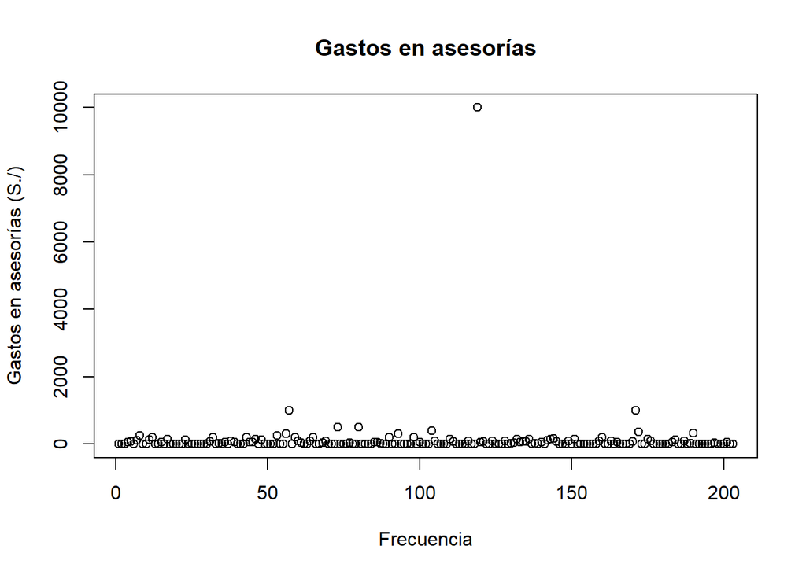

```r
plot(DF$`¿Cuánto has gastado en asesorías adicionales para tus cursos este ciclo?`, ylab = "Gastos en asesorías (S./)", xlab="Frecuencia", main="Gastos en asesorías")
```

Por lo que nos damos cuenta que hay que realizar una limpieza un poco más intensiva:

```r
DF$`¿Cuánto has gastado en asesorías adicionales para tus cursos este ciclo?`[DF$`¿Cuánto has gastado en asesorías adicionales para tus cursos este ciclo?` == "10000"] <- "0"
DF$`¿Cuánto has gastado en asesorías adicionales para tus cursos este ciclo?`[DF$`¿Cuánto has gastado en asesorías adicionales para tus cursos este ciclo?` == "0.5"] <- "0"
DF$`¿Cuánto has gastado en asesorías adicionales para tus cursos este ciclo?`[DF$`¿Cuánto has gastado en asesorías adicionales para tus cursos este ciclo?` == "1"] <- "0"
DF$`¿Cuánto has gastado en asesorías adicionales para tus cursos este ciclo?`[DF$`¿Cuánto has gastado en asesorías adicionales para tus cursos este ciclo?` == "2"] <- "0"
DF$`¿Cuánto has gastado en asesorías adicionales para tus cursos este ciclo?`[DF$`¿Cuánto has gastado en asesorías adicionales para tus cursos este ciclo?` == "3"] <- "0"
DF$`¿Cuánto has gastado en asesorías adicionales para tus cursos este ciclo?`[DF$`¿Cuánto has gastado en asesorías adicionales para tus cursos este ciclo?` == "4"] <- "0"
DF$`¿Cuánto has gastado en asesorías adicionales para tus cursos este ciclo?`[DF$`¿Cuánto has gastado en asesorías adicionales para tus cursos este ciclo?` == "00"] <- "0"
```

Después procedemos a realizar el cambio de carácter a numérico:

```r
DF$`¿Cuánto has gastado en asesorías adicionales para tus cursos este ciclo?`<- as.numeric(DF$`¿Cuánto has gastado en asesorías adicionales para tus cursos este ciclo?`)
```

Verificamos que hayamos hecho nuestra limpieza de una manera adecuada:

```r
unique(DF$`¿Cuánto has gastado en asesorías adicionales para tus cursos este ciclo?`)
```

```
##  [1]    0   50   75  110  250  125  200  150  130   70   15  100  300 1000   40
## [16]  500   46   60   20  400   80   25   30  155  360  120  320
```

```r
class(DF$`¿Cuánto has gastado en asesorías adicionales para tus cursos este ciclo?`)
```

```
## [1] "numeric"
```

*Sueño*:

```r
unique(DF$`¿Cuántas son tus horas de sueño promedio?`)
```

```
##  [1]  8.0  9.0  6.0  7.0  4.5  5.0  7.3  4.0  6.5 10.0  6.3  5.3  2.0  0.0 12.0
## [16]  7.5  4.3
```

```r
DF$`¿Cuántas son tus horas de sueño promedio?` <- gsub("0", "", DF$`¿Cuántas son tus horas de sueño promedio?`)
DF$`¿Cuántas son tus horas de sueño promedio?` <- gsub("1", "", DF$`¿Cuántas son tus horas de sueño promedio?`)
DF$`¿Cuántas son tus horas de sueño promedio?`[DF$`¿Cuántas son tus horas de sueño promedio?` == "6.5"] <- "6.3"
DF$`¿Cuántas son tus horas de sueño promedio?`[DF$`¿Cuántas son tus horas de sueño promedio?` == "4.5"] <- "4.3"
```

```r
DF$`¿Cuántas son tus horas de sueño promedio?`[DF$`¿Cuántas son tus horas de sueño promedio?` == ""] <- NA
```

Finalmente cambiamos el valor de la variable de caractér a numérico y verificamos que hayamos hecho el procedimiento correcto:

```r
DF$`¿Cuántas son tus horas de sueño promedio?`<-as.numeric(DF$`¿Cuántas son tus horas de sueño promedio?`)
```

```r
unique(DF$`¿Cuántas son tus horas de sueño promedio?`)
```

```
##  [1] 8.0 9.0 6.0 7.0 4.3 5.0 7.3 4.0 6.3  NA 5.3 2.0 7.5
```

```r
class(DF$`¿Cuántas son tus horas de sueño promedio?`)
```

```
## [1] "numeric"
```

*Motivos de deserción*:

Procesamos todos los datos que se deban limpiar y los cambiamos:

```r
DF$`Si la respuesta anterior es sí, ¿Por qué motivos?`[DF$`Si la respuesta anterior es sí, ¿Por qué motivos?` == "Marque no"] <- "No dejaría la universidad"
DF$`Si la respuesta anterior es sí, ¿Por qué motivos?`[DF$`Si la respuesta anterior es sí, ¿Por qué motivos?` == "Respondí que no"] <- "No dejaría la universidad"
DF$`Si la respuesta anterior es sí, ¿Por qué motivos?`[DF$`Si la respuesta anterior es sí, ¿Por qué motivos?` == "."] <- "No dejaría la universidad"
DF$`Si la respuesta anterior es sí, ¿Por qué motivos?`[DF$`Si la respuesta anterior es sí, ¿Por qué motivos?` == "Ninguno."] <- "No dejaría la universidad"
DF$`Si la respuesta anterior es sí, ¿Por qué motivos?`[DF$`Si la respuesta anterior es sí, ¿Por qué motivos?` == "Marque no :)"] <- "No dejaría la universidad"
DF$`Si la respuesta anterior es sí, ¿Por qué motivos?`[DF$`Si la respuesta anterior es sí, ¿Por qué motivos?` == "respondí no"] <- "No dejaría la universidad"
DF$`Si la respuesta anterior es sí, ¿Por qué motivos?`[DF$`Si la respuesta anterior es sí, ¿Por qué motivos?` == "No la considero dejar"] <- "No dejaría la universidad"
DF$`Si la respuesta anterior es sí, ¿Por qué motivos?`[DF$`Si la respuesta anterior es sí, ¿Por qué motivos?` == "No dejare"] <- "No dejaría la universidad"
DF$`Si la respuesta anterior es sí, ¿Por qué motivos?`[DF$`Si la respuesta anterior es sí, ¿Por qué motivos?` == "No pienso dejar la universidad"] <- "No dejaría la universidad"
DF$`Si la respuesta anterior es sí, ¿Por qué motivos?`[DF$`Si la respuesta anterior es sí, ¿Por qué motivos?` == "No lo dejaría"] <- "No dejaría la universidad"
DF$`Si la respuesta anterior es sí, ¿Por qué motivos?`[DF$`Si la respuesta anterior es sí, ¿Por qué motivos?` == "Ninguno"] <- "No dejaría la universidad"
DF$`Si la respuesta anterior es sí, ¿Por qué motivos?`[DF$`Si la respuesta anterior es sí, ¿Por qué motivos?` == "No"] <- "No dejaría la universidad"
DF$`Si la respuesta anterior es sí, ¿Por qué motivos?`[DF$`Si la respuesta anterior es sí, ¿Por qué motivos?` == "No pienso en ello"] <- "No dejaría la universidad"
DF$`Si la respuesta anterior es sí, ¿Por qué motivos?`[DF$`Si la respuesta anterior es sí, ¿Por qué motivos?` == "no"] <- "No dejaría la universidad"
DF$`Si la respuesta anterior es sí, ¿Por qué motivos?`[DF$`Si la respuesta anterior es sí, ¿Por qué motivos?` == "Puse no"] <- "No dejaría la universidad"
DF$`Si la respuesta anterior es sí, ¿Por qué motivos?`[DF$`Si la respuesta anterior es sí, ¿Por qué motivos?` == "-"] <- "No dejaría la universidad"
DF$`Si la respuesta anterior es sí, ¿Por qué motivos?`[DF$`Si la respuesta anterior es sí, ¿Por qué motivos?` == "Nada"] <- "No dejaría la universidad"
DF$`Si la respuesta anterior es sí, ¿Por qué motivos?`[DF$`Si la respuesta anterior es sí, ¿Por qué motivos?` == "no considero dejar la universidad"] <- "No dejaría la universidad"
DF$`Si la respuesta anterior es sí, ¿Por qué motivos?`[DF$`Si la respuesta anterior es sí, ¿Por qué motivos?` == "Dije no xd"] <- "No dejaría la universidad"
DF$`Si la respuesta anterior es sí, ¿Por qué motivos?`[DF$`Si la respuesta anterior es sí, ¿Por qué motivos?` == "Ninguna"] <- "No dejaría la universidad"
DF$`Si la respuesta anterior es sí, ¿Por qué motivos?`[DF$`Si la respuesta anterior es sí, ¿Por qué motivos?` == "deporte"] <- "Deporte"
DF$`Si la respuesta anterior es sí, ¿Por qué motivos?`[DF$`Si la respuesta anterior es sí, ¿Por qué motivos?` == "No hay ingles"] <- "No hay inglés"
DF$`Si la respuesta anterior es sí, ¿Por qué motivos?`[DF$`Si la respuesta anterior es sí, ¿Por qué motivos?` == "NO"] <- "No dejaría la universidad"
DF$`Si la respuesta anterior es sí, ¿Por qué motivos?`[DF$`Si la respuesta anterior es sí, ¿Por qué motivos?` == "La respuesta anterior fue \"No\""] <- "No dejaría la universidad"
DF$`Si la respuesta anterior es sí, ¿Por qué motivos?`[DF$`Si la respuesta anterior es sí, ¿Por qué motivos?` == "No, porque me gusta la universidad"] <- "No dejaría la universidad"
DF$`Si la respuesta anterior es sí, ¿Por qué motivos?`[DF$`Si la respuesta anterior es sí, ¿Por qué motivos?` == "No planeo dejar la"] <- "No dejaría la universidad"
DF$`Si la respuesta anterior es sí, ¿Por qué motivos?`[DF$`Si la respuesta anterior es sí, ¿Por qué motivos?` == "a"] <- "No dejaría la universidad"
DF$`Si la respuesta anterior es sí, ¿Por qué motivos?`[DF$`Si la respuesta anterior es sí, ¿Por qué motivos?` == "Ya voy a terminar la carrera, falta poco"] <- "No dejaría la universidad"
DF$`Si la respuesta anterior es sí, ¿Por qué motivos?`[DF$`Si la respuesta anterior es sí, ¿Por qué motivos?` == "Seguir luchando por mis sueños"] <- "No dejaría la universidad"
```

Después comprobamos si es que realizamos la limpieza correctamente con:

```r
unique(DF$`Si la respuesta anterior es sí, ¿Por qué motivos?`)
```

```
##  [1] "Cansancio"                 "Altos costos"
##  [3] "Desgaste emocional"        "No dejaría la universidad"
##  [5] "Circunstancias familiares" "Todo"
##  [7] "Alto nivel de dificultad"  "Año sabático"
##  [9] "No hay inglés"             "Deporte"
```

# 3 Análisis descriptivo

Con la data ya limpia y corregida, podemos proceder a realizar nuestro análisis descriptivo de las distintas variables que resulten más importantes para nuestra investigación y relacionarlas.

## 3.1 Media, mediana y moda de edad

Con esto podemos encontrar la tendencia de los alumnos de la universidad que respondieron nuestra encuesta.

```r
mode <- function(x) {
   return(as.numeric(names(which.max(table(x)))))
}
```

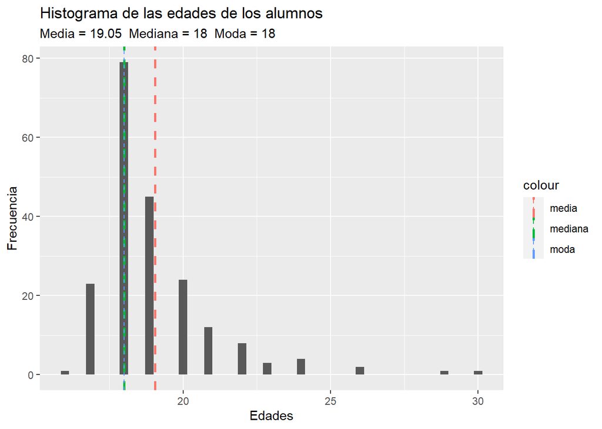

```r
media <- mean(DF$Edad)
edadSort <- sort(DF$Edad)
mediana <- median(edadSort)
moda <- mode(DF$Edad)

titulo <- "Histograma de las edades de los alumnos"
subtitulo <- paste("Media =",round(media,2), " Mediana =",mediana, " Moda =",moda)

ggplot(data = DF, mapping = aes(x=Edad)) +
  geom_histogram(bins=50) +
   ggtitle(titulo, subtitle = subtitulo) +
  xlab('Edades') + ylab('Frecuencia') +
  geom_vline(aes(xintercept = media,
                  color = "media"),
              linetype = "dashed",
              size = 1)  +
   geom_vline(aes(xintercept = mediana,
                  color = "mediana"),
              linetype = "dashed",
              size = 1) +
   geom_vline(aes(xintercept = moda,
                  color = "moda"),
              linetype = "dashed",
              size = 0.5)
```

Dentro de nuestros datos, encontramos que tenemos una media de edad de 19.05 años, además de una media de 18 años y una moda con la misma cantidad.

## 3.2 Relación edad con si busca retirarse de la universidad

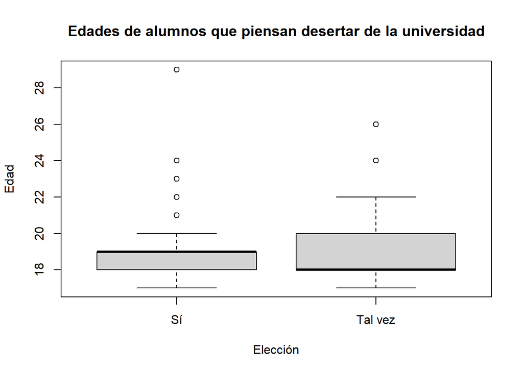

```r
DF_desertar <-filter(DF, DF$`¿Considerarías dejar la universidad?` != "No")
plot(factor(DF_desertar$`¿Considerarías dejar la universidad?`), DF_desertar$Edad, xlab = "Elección", ylab = "Edad", main = "Edades de alumnos que piensan desertar de la universidad")
```

**Análisis**

Con esta gráfica podemos apreciar que el querer retirarse de la universidad, reside principalmente entre las edades de 18 a 20 años, que es la edad donde se cursan los primeros semestres normalmente.

## 3.3 Relación entre desertar de la universidad y motivos.

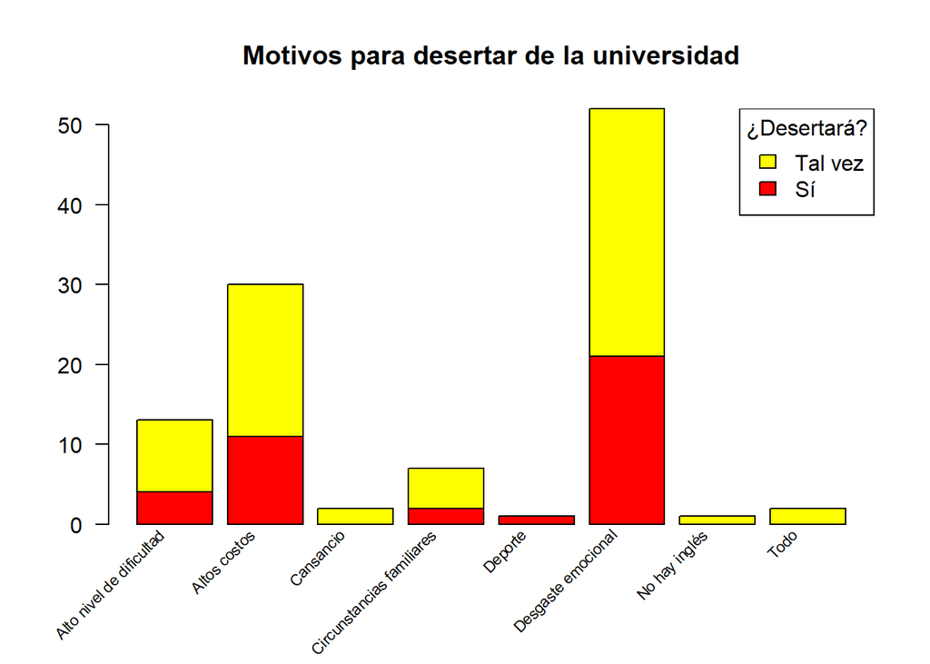

```r
DF_mod <- filter(DF, DF$`¿Considerarías dejar la universidad?` !="No" & DF$`Si la respuesta anterior es sí, ¿Por qué motivos?` != "No dejaría la universidad")

Desertar <- table(DF_mod$`¿Considerarías dejar la universidad?`,DF_mod$`Si la respuesta anterior es sí, ¿Por qué motivos?`)

colnames(Desertar) <- c("Alto nivel de dificultad", "Altos costos","Cansancio", "Circunstancias familiares","Deporte", "Desgaste emocional","No hay inglés", "Todo" )

x <-barplot(Desertar, las = 2, xaxt="n", col=c("red", "yellow"), main = "Motivos para desertar de la universidad")

text(cex=0.7, x=x, y=-1, colnames(Desertar), xpd=TRUE, srt=45, pos=2)
legend(x = "topright", legend = c("Tal vez", "Sí"), fill=c("yellow", "red"), title="¿Desertará?")
```

**Análisis**

Con esta gráfica, podemos concluir que existe una relación clara, entre el “Desgaste emocional” y “Altos costos” con relación a las probabilidades de que los alumnos si piensen en retirarse. Por otro lado para los que están en la opción de “Tal vez” se puede apreciar el mismo comportamiento.

## 3.4 Relación de horas de sueño con el desgaste emocional

Al momento de realizar las entrevistas y revisar la data inicial pudimos observar que existe un problema con el desgaste emocional, por lo que podríamos relacionarlo con las horas de sueño de cada alumno.

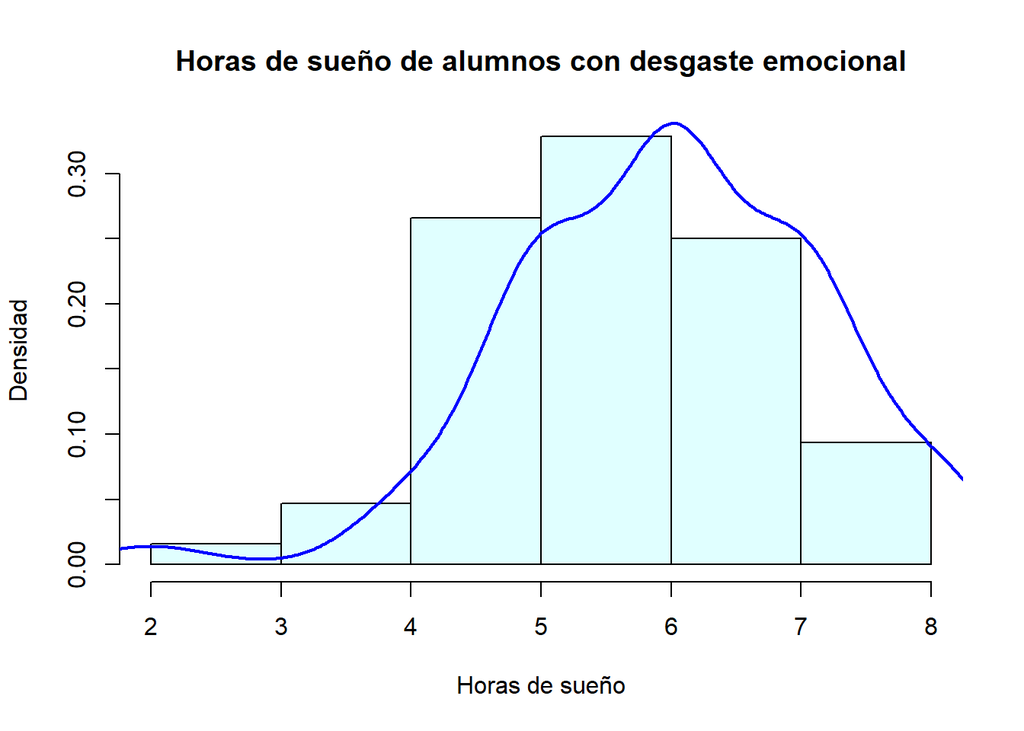

```r
DF_dormir <- filter(DF, DF$`Si la respuesta anterior es sí, ¿Por qué motivos?` == "Desgaste emocional")

hist(DF_dormir$`¿Cuántas son tus horas de sueño promedio?`, main = "Horas de sueño de alumnos con desgaste emocional", ylab = "Densidad", xlab = "Horas de sueño", col = "lightcyan", freq = F)
lines(density(DF_dormir$`¿Cuántas son tus horas de sueño promedio?`), lwd = 2, col = 'blue')
```

```r
mode(DF$`¿Cuántas son tus horas de sueño promedio?`)
```

```
## [1] 6
```

**Análisis**

## 3.5 Relación de altos costos con escala de pago

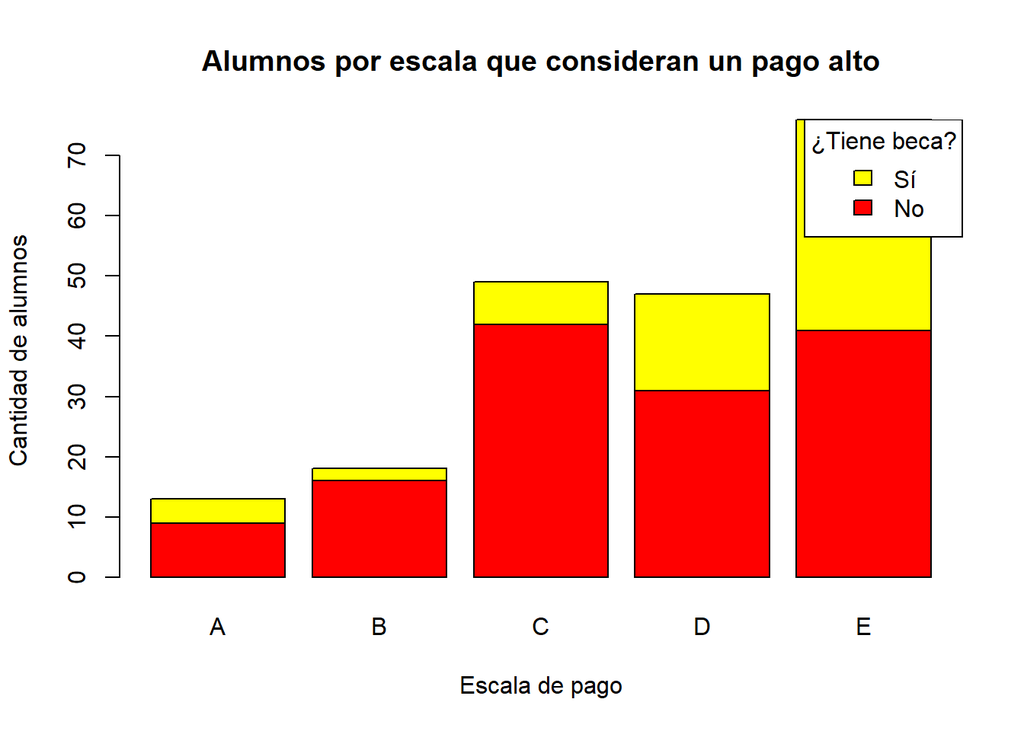

```r
DF_pago <- filter(DF, DF$`Si la respuesta anterior es sí, ¿Por qué motivos?` == "Altos costos")
DF_pago <- table(DF$`¿Cuentas con algún tipo de Beca?`, DF$`¿En qué escala de pago te encuentras?`)
barplot(DF_pago , ylab = "Cantidad de alumnos", xlab = "Escala de pago", col = c("red", "yellow"), main="Alumnos por escala que consideran un pago alto")
legend(x = "topright", legend = c("Sí", "No"), fill=c("yellow", "red"), title="¿Tiene beca?")
```

## 3.6 Relación de desgaste emocional con promedio ponderado

Dándonos cuenta que el número en cuanto a promedios ponderados que más se repite entre los encuestados podemos proceder a realizar una gráfica para revisar si se cumple la relación de que la mayor cantidad de alumnos tiene promedios cercanos a la moda.

```r
mode(DF$`Promedio ponderado`)
```

```
## [1] 15
```

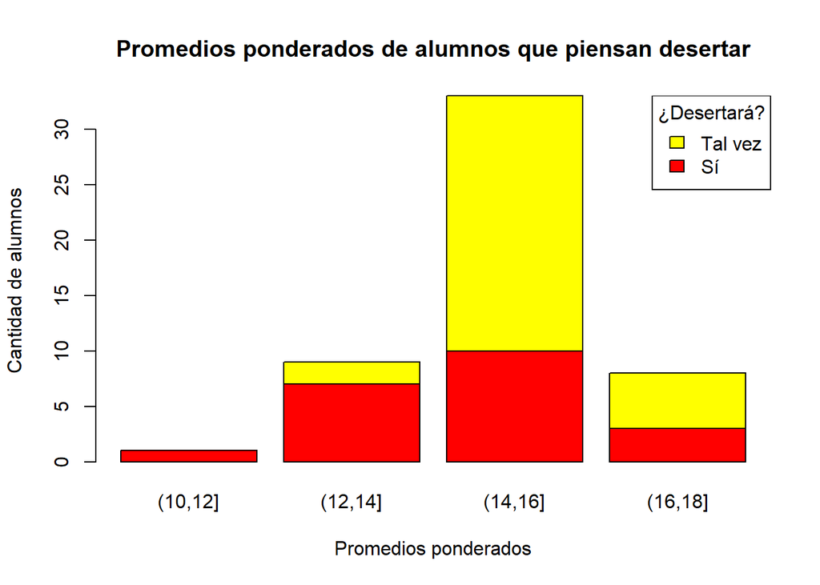

```r
DF_prom <- filter(DF, DF$`Si la respuesta anterior es sí, ¿Por qué motivos?` == "Desgaste emocional" & DF$`¿Considerarías dejar la universidad?` != "No")
DF_prom <- table(DF_prom$`¿Considerarías dejar la universidad?`,cut(DF_prom$`Promedio ponderado`, breaks = c(10, 12, 14, 16, 18)))
barplot(DF_prom, ylab = "Cantidad de alumnos", xlab = "Promedios ponderados", col = c("red", "yellow" ), main = "Promedios ponderados de alumnos que piensan desertar")
legend(x = "topright", legend = c("Tal vez", "Sí"), fill=c("yellow", "red"), title="¿Desertará?")
```

Pudimos darnos cuenta que, efectivamente, la mayor cantidad de alumnos poseen un promedio ponderado cercano a la moda obtenida. De igual manera, podemos relacionar la relevancia de lo obtenido en la gráfica con el grado de dificultad que se le considera a los cursos

```r
mode(DF$`Grado de dificultad promedio de los cursos de este ciclo`)
```

```
## [1] 7
```

```r
mean(DF$`Grado de dificultad promedio de los cursos de este ciclo`)
```

```
## [1] 7.571429
```

Teniendo que el promedio y la moda de la dificultad promedio son parecidos, podemos proceder a realizar otra gráfica que se encargue de evaluar lo mismo que la anterior, pero considerando el grado de dificultad que consideran los estudiantes respecto a los cursos a los que se matricularon este ciclo en vez del promedio ponderado.

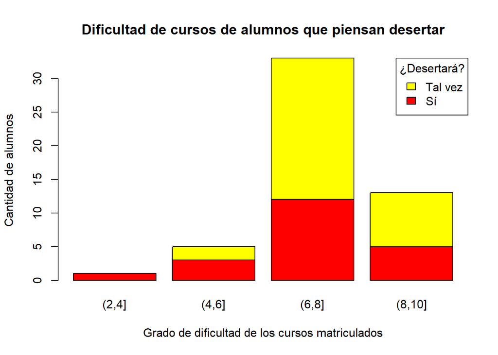

```r
DF_prom <- filter(DF, DF$`Si la respuesta anterior es sí, ¿Por qué motivos?` == "Desgaste emocional" & DF$`¿Considerarías dejar la universidad?` != "No")
DF_prom <- table(DF_prom$`¿Considerarías dejar la universidad?`,cut(DF_prom$`Grado de dificultad promedio de los cursos de este ciclo`, breaks = c(2, 4, 6, 8, 10)))
barplot(DF_prom, col = c("red", "yellow"), ylab = "Cantidad de alumnos", xlab = "Grado de dificultad de los cursos matriculados", main = "Dificultad de cursos de alumnos que piensan desertar")
legend(x = "topright", legend = c("Tal vez", "Sí"), fill=c("yellow", "red"), title="¿Desertará?")
```

**Análisis** En cuanto a esta relación de ambas variables del primer gráfico, segmentamos las notas para una mayor facilidad de interpretación. Por lo que, encontramos que en gran mayoría de los alumnos con promedio de 14 a 16, tienen un mayor desgaste emocional, pudiendo concluir que esto es debido a un sobre-esfuerzo que deben realizar para alcanzar dicho promedios.Para el segundo gráfico pudimos observar que de todos los alumnos que marcaron que se retirarían debido al Desgaste Emocional, la mayoría considera que la dificultad de los cursos; en una escala del 1 al 10, siendo 1 fácil y 10 muy difícil; van por sobre el 6.

# 4 Análisis probabilístico

## 4.1 Variables aleatorias conocidas (Modelos teóricos)

**Variable: Edad**

Consideremos que queremos elegir 45 estudiantes al azar, considerando que en UTEC las aulas son en su mayoría de 45 estudiantes. Planteamos como caso de éxito el hecho de que los estudiantes elegidos sean mayores de edad (+18), ya que de acuerdo a nuestra muestra, son quienes participaron más en nuestra encuesta.

X -> número de estudiantes mayores de 18 años en una aula de 45 alumnos

n -> número de muestras (45 encuestados)

**Ejemplo:** Si queremos saber la probabilidad de que por lo menos 23 de ellos sean mayores de edad (+18) podemos plantear lo siguiente:

```r
pbinom(22, size = 45, prob = 0.329, lower.tail = FALSE)
```

```
## [1] 0.008674601
```

**Variable: Deseo de deserción**

Consideremos que queremos elegir a 100 estudiantes al azar, aproximadamente el número de personas que circulan en el Piso 6. Planteamos como caso de éxito el hecho de que **SÍ** consideren desertar, ya que es el tema de interés de nuestro estudio, puede plantearse con un **Modelo Binomial**.

La probabilidad de que hayan respondido **SÍ**, para nuestro caso sería de 39/203, equivalente a 0.192 aproximadamente. Entonces el **Modelo Binomial** se define de la siguiente manera:

X -> Número de alumnos que SÍ decidirían desertar en un conjunto de 100 estudiantes del Piso 6

$$\mathbb{X}\sim \mathbb
{Bin}(100,0.192)$$

n -> número de muestras (100 encuestados)

La probabilidad de que hayan respondido **SÍ o TAL VEZ**, para nuestro caso sería de 110/203, equivalente a 0.542 aproximadamente. Entonces el **Modelo Binomial** se vería de la siguiente manera:

X ->Número de alumnos que **SÍ o TAL VEZ** decidirían desertar en un conjunto de 100 estudiantes del Piso 6.

$$\mathbb{X} \sim \mathbb
{Bin}(100,0.542)$$

n -> número de muestras (100 encuestados)

p -> probabilidad de que la persona seleccionada **SÍ o TAL VEZ** desee desertar (110/203)

**Ejemplo:** queremos saber la probabilidad de que por lo menos 30 de ellos deseen o se planteen desertar para SÍ y para SÍ y TAL VEZ

Para el caso de que **SÍ** estén seguros de desertar:

```r
pbinom(29, size =100, prob = 0.192, lower.tail = FALSE)
```

```
## [1] 0.006296983
```

Para el caso de **SÍ** estén seguros o de que **TAL VEZ** consideren desertar:

```r
pbinom(29, size =100, prob = 0.542, lower.tail = FALSE)
```

```
## [1] 0.9999997
```

**Variable: Satisfacción con Rutina diaria**

Consideremos que queremos saber cuanto nos demoraríamos en encontrar a alguien que esté completamente satisfecho con su rutina diaria (que hayan marcado un 5 de 5 en satisfacción en nuestra encuesta para la pregunta de “¿Qué tan satisfecho te encuentras con tu rutina actual?”) planteando dicha situación como caso de éxito, ya que dicha situación sería la óptima para un alumno universitario que desea estar bien organizado con sus cursos. De dicha manera es que podemos plantear un **Modelo Geométrico.**

X -> Número de intentos hasta que se detecte a un alumno que haya marcado 5 de 5 en satisfacción completa con su rutina diaria en un grupo de 50 personas

$$\mathbb{X}\sim \mathbb
{Geo}(50,0.009)$$

x -> Cantidad de personas en el grupo

p -> Probabilidad de que hayan marcado un 5 en la escala de satisfacción

```r
dgeom(x=51, prob = 0.01)
```

```
## [1] 0.00598956
```

**Variable: Horas de sueño**

Consideremos que queremos elegir 50 estudiantes al azar, considerando la cantidad de personas que se encuentran en total en la sala de estudios de la UTEC en el Piso 1. Planteamos como caso de éxito el hecho de que duerman entre 6 y 8 horas, ya que estas son un número de horas de sueño apropiadas, podemos plantear un **Modelo Uniforme Continuo**.

X ->Estudiantes que duermen entre 8 y 6 horas entre un grupo de 50 estudiantes en la sala de estudio del Piso 1

$$F(X) = P(x\leq X) = \begin{cases} & 0\text{ si } X< 2 \\ &
\int_{6}^{8}\frac{1}{12-2} \mathit{ dx} = \frac{6-2}{12-2}\text{ si }
2\leq 8\leq 12\\ & 1\text{ si } X\geq 12\end{cases}$$

min -> 2 horas

max -> 12 horas

intervalo -> 8 - 6 horas

$$f(x) = 1/(12-2)$$

$$P(X) = P(6\leq x\leq 8) = \int_{6}^{8}\frac{1}{10} {dx}$$

**Ejemplo:** Queremos saber la probabilidad de que cierta cantidad de alumnos tiene horas de sueño saludables que se encuentran en un intervalo de entre 6 y 8 horas

```r
punif(q = 8, min = 2, max = 12) - punif(q = 6, min = 2, max = 12)
```

```
## [1] 0.2
```

**Variable: Consideración de altos costos**

Consideremos que queremos elegir a 80 estudiantes al azar, aproximadamente el número de personas que almuerzan en la cafetería de la UTEC. Planteamos como caso de éxito el hecho de que *SÍ* consideran que los precios son altos, ya que es uno de los temas de interés de nuestro estudio. Esto podría plantearse con un **Modelo Binomial**.

La probabilidad de que hayan respondido *SÍ*, para nuestro caso sería de 165/203, equivalente a 0.813 aproximadamente. Entonces el **Modelo Binomial** se vería de la siguiente manera:

X -> Número de alumnos que SÍ consideran que los precios para las pensiones son altos en un conjunto de 80 estudiantes en el comedor

$$\mathbb{X} \sim \mathbb
{Bin}(80,0.813)$$

n -> número de muestras (80 encuestados)

p -> probabilidad de que la persona seleccionada *SÍ* considera altos precios (165/203)

**Ejemplo:** Queremos saber la probabilidad de que por lo menos 60 de ellos no estén conformes con los altos precios

```r
pbinom(59, size =80, prob = 0.813, lower.tail = FALSE)
```

```
## [1] 0.9395988
```